# **Introduction**

Historically, men have been understudied and underrepresented in disordered eating research (Braun et al., 1999; Lavender et al., 2017). Yet, increasing and compelling data indicate that young men between the ages of 18-30, in particular, report high rates of disordered eating symptoms (Braun et al., 1999; Strother et al., 2012). Excessive exercise and muscularity-enhancing behaviors may be especially applicable to young men, given the current sociocultural pressures for young men to embody the mesomorphic body ideal (e.g., a lean and muscular physique) (Lavender et al., 2017). Indeed, many men report being dissatisfied with their bodies and a desire to reduce their fat mass and increase their muscle mass (Pope, Phillips, & Olivardia, 2000; Baghurst, Hollander, Nardella, & Haff, 2006). Excessive exercise aimed at enhancing muscularity may function to reduce body dissatisfaction while also simultaneously working towards achieving the mesomorphic body ideal. Although excessive exercise and muscularity-enhancing behaviors are rampant in young men (Spann & Pritchard, 2008), little is known about sociocultural risk factors that precipitate and maintain these behaviors. Extant data suggest that Asian/Asian American men report the most severe disordered eating symptoms, such as muscularity-enhancing behaviors, across racial/ethnic groups (Kelly et al., 2015; Strother et al., 2012). Indeed, Asian/Asian American men often rate their bodies as smaller than their ideal physique (Barnett et al., 2002). Potential romantic partners also rate Asian/Asian American men as less masculine and more feminine than their non-Asian counterparts (Wilkins et al., 2011). These harmful stereotypes may render Asian/Asian American men especially susceptible to engaging in muscularity-enhancing behaviors in an effort to achieve the mesomorphic body ideal. Evidently, harmful stereotypes have a profound effect on Asian/Asian American men’s body image and associated disordered eating behaviors. Racial discrimination, in the forms of both overt racism and microaggressions, may be particularly relevant to Asian/Asian American men’s behavioral drive for muscularity (Nadal et al., 2014). Preliminary data suggest that overt racism (e.g., “Asian Americans were historically targets of racism”) and microaggressions (e.g., “a student you do not know asks you for help in math”) are positively associated with disinhibited eating in young, Asian/Asian American men (e.g., binge eating and loss of control eating) (Kelly et al., 2018). However, no studies to date have identified if experiences with overt racism and microaggressions are linked to muscularity enhancing behaviors, specifically (e.g., body building, metabolic steroid use, excessive weightlifting) in young Asian/Asian American men.

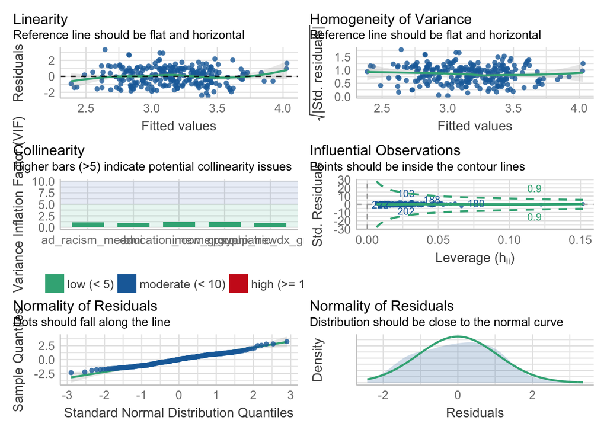

```
##
## Call:
## lm(formula = dms_mean ~ income_group_new + education_new_group +
##     bmi + psychiatric_dx_group + ad_racism_mean, data = asian_men)
##
## Residuals:
##     Min      1Q  Median      3Q     Max
## -2.4296 -0.8159  0.0014  0.7719  3.3548
##
## Coefficients:
##                       Estimate Std. Error t value Pr(>|t|)
## (Intercept)           2.205374   0.398803   5.530 8.05e-08 ***
## income_group_new      0.094716   0.056726   1.670 0.096229 .
## education_new_group  -0.040695   0.090255  -0.451 0.652461
## bmi                   0.004074   0.012342   0.330 0.741620
## psychiatric_dx_group -0.220569   0.171103  -1.289 0.198556
## ad_racism_mean        0.274068   0.075004   3.654 0.000315 ***
## ---
## Signif. codes:  0 '***' 0.001 '**' 0.01 '*' 0.05 '.' 0.1 ' ' 1
##
## Residual standard error: 1.075 on 250 degrees of freedom
##   (10 observations deleted due to missingness)
## Multiple R-squared:  0.07514,    Adjusted R-squared:  0.05664
## F-statistic: 4.062 on 5 and 250 DF,  p-value: 0.001458
```

```
##
## Call:
## lm(formula = dms_mean ~ income_group_new + education_new_group +
##     bmi + psychiatric_dx_group + ad_microaggr_mean, data = asian_men)
##
## Residuals:
##     Min      1Q  Median      3Q     Max
## -2.8897 -0.7339  0.0185  0.7094  3.3881
##
## Coefficients:
##                       Estimate Std. Error t value Pr(>|t|)
## (Intercept)           2.099064   0.385157   5.450 1.21e-07 ***
## income_group_new      0.107461   0.055032   1.953    0.052 .
## education_new_group  -0.044491   0.088309  -0.504    0.615
## bmi                   0.002432   0.012083   0.201    0.841
## psychiatric_dx_group -0.160033   0.166991  -0.958    0.339
## ad_microaggr_mean     0.383180   0.076431   5.013 1.01e-06 ***
## ---
## Signif. codes:  0 '***' 0.001 '**' 0.01 '*' 0.05 '.' 0.1 ' ' 1
##
## Residual standard error: 1.051 on 250 degrees of freedom
##   (10 observations deleted due to missingness)
## Multiple R-squared:  0.1147, Adjusted R-squared:  0.09704
## F-statistic: 6.481 on 5 and 250 DF,  p-value: 1.098e-05
```

[output not shown]